# Diasatolic-Blood Pressure ~ Moisture

Updated on : Fri Sep 02 15:08:26 2022

## Load libs and Load data

The process of load libs and data is the same as [EnWAS sample](https://ccb-hms.github.io/Imputation/7_enwas/EnWAS_simple.html) and [Diastolic: EnWAS](https://ccb-hms.github.io/Imputation/7_enwas/blood_pres/blood_pres_diastolic.html).

## DR1TMOIS - Moisture (0 to 18266.25 gm)

“Moisture in foods occurs in two forms: (1) water bound to ingredients in the food (proteins, salt, sugars), and (2) free or unbound water that is available for microbial growth. Water activity (Aw) describes water available for microbial growth and ranges from 0 (bone dry) to 1.0 (pure water).” [more infor](https://www.clemson.edu/extension/food/canning/canning-tips/39available-moisture.html)

```r
linear_model <- 'BPXDI1 ~ RIDAGEYR*RIAGENDR + BMXBMI'

ns_model <-
  'BPXDI1 ~ ns(RIDAGEYR, knots
= seq(20, 80, by = 10)) * RIAGENDR + ns(BMXBMI,knots = c(seq(15, 45, by = 5),seq(45,65,by=10))) '
lm_base <- lm(as.formula(linear_model), data)
ns_base <- lm(as.formula(ns_model), data)


lm_mos_model <- 'DR1TMOIS ~ RIDAGEYR*RIAGENDR + BMXBMI'

ns_mos_model <-
  'DR1TMOIS ~ ns(RIDAGEYR, knots
= seq(20, 80, by = 10)) * RIAGENDR + ns(BMXBMI,knots = c(seq(15, 45, by = 5),seq(45,65,by=10))) '
lm_mos <- lm(as.formula(lm_mos_model), data)
ns_mos <- lm(as.formula(ns_mos_model), data)
```

### Partial regression plot

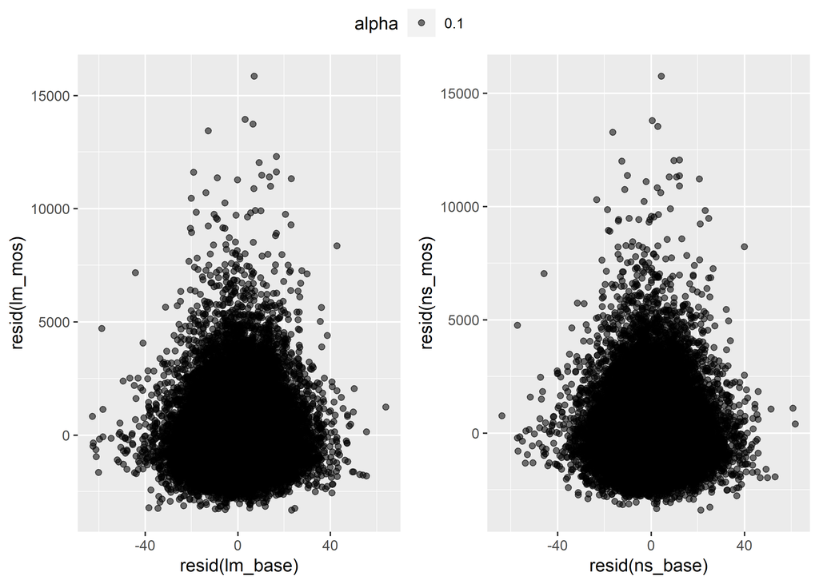

```r
g1<- qplot(resid(lm_base),resid(lm_mos),alpha = 0.1)
g2 <- qplot(resid(ns_base),resid(ns_mos),alpha = 0.1)
ggpubr::ggarrange(g1,g2,common.legend = TRUE)
```

## Beta-carotene (0 to 116313 mcg): inverse normal transformation

“The human body converts beta carotene into vitamin A (retinol) – beta carotene is a precursor of vitamin A. We need vitamin A for healthy skin and mucus membranes, our immune system, and good eye health and vision.” [more](https://www.medicalnewstoday.com/articles/252758#what_is_carotene)

“If the residual distribution is asymmetric (skewed) or heavy-tailed (kurtotic) relative to the normal distribution, then standard linear regression may fail to control the type I error in moderate samples. Even if the sample is sufficiently large for standard linear regression to provide valid inference, it is not fully efficient when the residual distribution is non-normal.” [more](https://cran.r-project.org/web/packages/RNOmni/vignettes/RNOmni.html)